# Assignment_2

2022-10-24

## Combine the data with the overall meta analysis

```r
path <- "C:/Users/caleb/OneDrive/Documents/Courses/2022 Semester 2/BIOL3207/BIOL3207_Assignment_2/Assignment_2/OA_activitydat_20190302_BIOL3207.csv"


data <- read_csv(path)
```

```
## ──────────────────────────────────────────────────────── Delimiter: "," chr
## (5): loc, species, treatment, size, comment dbl (4): ...1, animal_id, sl,
## activity
```

```r
#tidying up the data by removal irrelevant columns
drop <- c("comment", "loc")
data <- data[!(names(data) %in% drop)]
```

```r
#checking spelling of each species and treatment
categories1 <- unique(data$species)
categories1
```

```
## [1] "ambon"     "lemon"     "chromis"   "acantho"   "humbug"    "whitedams"
```

```r
categories2 <- unique(data$treatment)
categories2
```

```
## [1] "CO2"     "control"
```

```r
#summarising the data
dataft <- data %>%
  drop_na %>%
  group_by(species, treatment) %>%
  summarise(
    n = n(),
    mean = mean(activity),
    sd = sd(activity)
  )
flextable(dataft)
```

| species | treatment | n | mean | sd |
| --- | --- | --- | --- | --- |
| acantho | CO2 | 86 | 27.30042 | 10.415559 |
| acantho | control | 90 | 28.92639 | 11.246347 |
| ambon | CO2 | 22 | 18.39429 | 12.200326 |
| ambon | control | 21 | 17.34102 | 11.451588 |
| chromis | CO2 | 14 | 24.78010 | 10.975005 |
| chromis | control | 20 | 26.09986 | 9.125352 |
| humbug | CO2 | 62 | 40.28306 | 11.915992 |
| humbug | control | 65 | 34.91652 | 13.867278 |
| lemon | CO2 | 19 | 26.04157 | 10.957164 |
| lemon | control | 30 | 19.79766 | 12.256353 |
| whitedams | CO2 | 60 | 24.45733 | 9.950437 |
| whitedams | control | 61 | 26.58624 | 10.936592 |

```r
#tidying data to fit into metadata layout
dataft[dataft == "control"] <- "ctrl"
dataft[dataft == "CO2"] <- "oa"
colnames(dataft)[1] <- "Species"

datalong <- pivot_longer(dataft, col = 3:5, names_to = "stat", values_to = "value")
datawide <- pivot_wider(datalong, names_from = c(treatment, stat), values_from = value, names_sep = ".")
datawide
```

```
## # A tibble: 6 × 7
## # Groups:   Species [6]
##   Species    oa.n oa.mean oa.sd ctrl.n ctrl.mean ctrl.sd
##   <chr>     <dbl>   <dbl> <dbl>  <dbl>     <dbl>   <dbl>
## 1 acantho      86    27.3 10.4      90      28.9   11.2
## 2 ambon        22    18.4 12.2      21      17.3   11.5
## 3 chromis      14    24.8 11.0      20      26.1    9.13
## 4 humbug       62    40.3 11.9      65      34.9   13.9
## 5 lemon        19    26.0 11.0      30      19.8   12.3
## 6 whitedams    60    24.5  9.95     61      26.6   10.9
```

```r
#import meta data from clark et al report
path2 <- "C:/Users/caleb/OneDrive/Documents/Courses/2022 Semester 2/BIOL3207/BIOL3207_Assignment_2/Assignment_2/clark_paper_data.csv"

data2 <- read_csv(path2)
data2
```

```
## # A tibble: 1 × 15
##   Study Authors    Year …¹ Year …² Title Journal Pub y…³ 2017 …⁴ Avera…⁵ Effec…⁶
##   <chr> <chr>        <dbl>   <dbl> <chr> <chr>     <dbl>   <dbl>   <dbl> <chr>
## 1 a92   Clark et …    2020    2020 Ocea… Nature     69.5    41.6      45 Weak
## # … with 5 more variables: `Climate (FishBase)` <chr>,
## #   `Env cue/stimulus?` <chr>, `Cue/stimulus type` <lgl>,
## #   `Behavioural metric` <chr>, `Life stage` <chr>, and abbreviated variable
## #   names ¹`Year (online)`, ²`Year (print)`, ³`Pub year IF`, ⁴`2017 IF`,
## #   ⁵`Average n`, ⁶`Effect type`
## # ℹ Use `colnames()` to see all variable names
```

```r
#merge the two data sets to correspond with the larger data set
datacomb <- merge(data2, datawide)
datacomb
```

```
##   Study     Authors Year (online) Year (print)
## 1   a92 Clark et al          2020         2020
## 2   a92 Clark et al          2020         2020
## 3   a92 Clark et al          2020         2020
## 4   a92 Clark et al          2020         2020
## 5   a92 Clark et al          2020         2020
## 6   a92 Clark et al          2020         2020
##                                                                    Title
## 1 Ocean acidification does not impair the behaviour of coral reef fishes
## 2 Ocean acidification does not impair the behaviour of coral reef fishes
## 3 Ocean acidification does not impair the behaviour of coral reef fishes
## 4 Ocean acidification does not impair the behaviour of coral reef fishes
## 5 Ocean acidification does not impair the behaviour of coral reef fishes
## 6 Ocean acidification does not impair the behaviour of coral reef fishes
##   Journal Pub year IF 2017 IF Average n Effect type Climate (FishBase)
```

[output cut: 20 more lines]

```r
path3 <- "C:/Users/caleb/OneDrive/Documents/Courses/2022 Semester 2/BIOL3207/BIOL3207_Assignment_2/Assignment_2/ocean_meta_data.csv"

data3 <- read_csv(path3)
data3
```

```
## # A tibble: 818 × 22
##    Study Authors   Year …¹ Year …² Title Journal Pub y…³ 2017 …⁴ Avera…⁵ Effec…⁶
##    <chr> <chr>       <dbl>   <dbl> <chr> <chr>   <chr>   <chr>     <dbl> <chr>
##  1 a1    Munday e…    2009    2009 Ocea… PNAS    9.432   9.504        27 Strong
##  2 a1    Munday e…    2009    2009 Ocea… PNAS    9.432   9.504        27 Strong
##  3 a1    Munday e…    2009    2009 Ocea… PNAS    9.432   9.504        27 Strong
##  4 a1    Munday e…    2009    2009 Ocea… PNAS    9.432   9.504        27 Strong
##  5 a1    Munday e…    2009    2009 Ocea… PNAS    9.432   9.504        27 Strong
##  6 a1    Munday e…    2009    2009 Ocea… PNAS    9.432   9.504        27 Strong
##  7 a1    Munday e…    2009    2009 Ocea… PNAS    9.432   9.504        27 Strong
##  8 a2    Dixson e…    2009    2010 Ocea… Ecol L… 10.318  9.137        15 Strong
##  9 a2    Dixson e…    2009    2010 Ocea… Ecol L… 10.318  9.137        15 Strong
## 10 a2    Dixson e…    2009    2010 Ocea… Ecol L… 10.318  9.137        15 Strong
## # … with 808 more rows, 12 more variables: Species <chr>,
## #   `Climate (FishBase)` <chr>, `Env cue/stimulus?` <chr>,
## #   `Cue/stimulus type` <chr>, `Behavioural metric` <chr>, `Life stage` <chr>,
## #   ctrl.n <dbl>, ctrl.mean <dbl>, ctrl.sd <dbl>, oa.n <dbl>, oa.mean <dbl>,
## #   oa.sd <dbl>, and abbreviated variable names ¹`Year (online)`,
## #   ²`Year (print)`, ³`Pub year IF`, ⁴`2017 IF`, ⁵`Average n`, ⁶`Effect type`
## # ℹ Use `print(n = ...)` to see more rows, and `colnames()` to see all variable names
```

```r
#combine the data into one final dataframe
datafinal <- rbind(data3, datacomb)
datafinal
```

```
## # A tibble: 824 × 22
##    Study Authors   Year …¹ Year …² Title Journal Pub y…³ 2017 …⁴ Avera…⁵ Effec…⁶
##    <chr> <chr>       <dbl>   <dbl> <chr> <chr>   <chr>   <chr>     <dbl> <chr>
##  1 a1    Munday e…    2009    2009 Ocea… PNAS    9.432   9.504        27 Strong
##  2 a1    Munday e…    2009    2009 Ocea… PNAS    9.432   9.504        27 Strong
##  3 a1    Munday e…    2009    2009 Ocea… PNAS    9.432   9.504        27 Strong
##  4 a1    Munday e…    2009    2009 Ocea… PNAS    9.432   9.504        27 Strong
##  5 a1    Munday e…    2009    2009 Ocea… PNAS    9.432   9.504        27 Strong
##  6 a1    Munday e…    2009    2009 Ocea… PNAS    9.432   9.504        27 Strong
##  7 a1    Munday e…    2009    2009 Ocea… PNAS    9.432   9.504        27 Strong
##  8 a2    Dixson e…    2009    2010 Ocea… Ecol L… 10.318  9.137        15 Strong
##  9 a2    Dixson e…    2009    2010 Ocea… Ecol L… 10.318  9.137        15 Strong
## 10 a2    Dixson e…    2009    2010 Ocea… Ecol L… 10.318  9.137        15 Strong
## # … with 814 more rows, 12 more variables: Species <chr>,
## #   `Climate (FishBase)` <chr>, `Env cue/stimulus?` <chr>,
## #   `Cue/stimulus type` <chr>, `Behavioural metric` <chr>, `Life stage` <chr>,
## #   ctrl.n <dbl>, ctrl.mean <dbl>, ctrl.sd <dbl>, oa.n <dbl>, oa.mean <dbl>,
## #   oa.sd <dbl>, and abbreviated variable names ¹`Year (online)`,
## #   ²`Year (print)`, ³`Pub year IF`, ⁴`2017 IF`, ⁵`Average n`, ⁶`Effect type`
## # ℹ Use `print(n = ...)` to see more rows, and `colnames()` to see all variable names
```

## Meta analysis

NaNs produced, which code is needed to prevent

```r
which(datafinal$ctrl.mean <=0 & datafinal$oa.mean > 0 | datafinal$ctrl.mean > 0 & datafinal$oa.mean <= 0)
```

```
##  [1]  89  91  93 121 127 128 129 130 137 141 142 155 223 228 229 278 279 282 338
## [20] 339 340 594 595
```

```r
#I attempted to adjust the values of different signs but was unsuccessful and the code just wouldn't work. Furthermore, how is the ctrl group for reports that tested against a baseline not equal to close to 0? As such I left them removed from the escalc function
```

[output not shown]

```r
names(dfeffect)[names(dfeffect) == "Behavioural metric"] <- "Behavioural.metric"
names(dfeffect)[names(dfeffect) == "Year (online)"] <- "Year.Pub"
```

```r
#meta-analytic model using the effect size and sampling variance of the escalc function. Random effect of the studies and within the studies using the species and behavioural metric within the species was used.
MA <- rma.mv(effect.size ~ 1, V = sampling.variance, method = "REML", random = list(~1 | Study/Species/Behavioural.metric), dfs = "contain", test = "t", data = dfeffect)
MA
```

```
##
## Multivariate Meta-Analysis Model (k = 801; method: REML)
##
## Variance Components:
##
##             estim    sqrt  nlvls  fixed                            factor
## sigma^2.1  0.3166  0.5626     92     no                             Study
## sigma^2.2  0.1844  0.4295    118     no                     Study/Species
## sigma^2.3  3.9823  1.9956    798     no  Study/Species/Behavioural.metric
##
## Test for Heterogeneity:
## Q(df = 800) = 736089064.6199, p-val < .0001
##
## Model Results:
##
## estimate      se     tval  df    pval    ci.lb   ci.ub
##  -0.1312  0.1130  -1.1611  91  0.2486  -0.3555  0.0932
##
## ---
## Signif. codes:  0 '***' 0.001 '**' 0.01 '*' 0.05 '.' 0.1 ' ' 1
```

The meta-analytic model fitted to the data conveys the overall meta-analytic mean effect size to be -0.1312 between the studies. The confidence intervals are -0.3555 and 0.0932, meaning there is a 95% confidence that the true mean of the studies to fall within this range. This means that there is no significance between the studies as shown by the p value being 0.2486 (>0.1). The null hypothesis cannot be rejected since 0 lies within the measures of uncertainty around the mean estimate.

```r
#heterogeneity of effect size using prediction intervals
predict(MA)
```

```
##
##     pred     se   ci.lb  ci.ub   pi.lb  pi.ub
##  -0.1312 0.1130 -0.3555 0.0932 -4.3430 4.0807
```

The prediction intervals of the meta-analytic model are -4.3430 and 4.0807. This is the expected variation of effect sizes over the studies and the 95% confidence that a new study will fall within this range, the heterogeneity of the results.

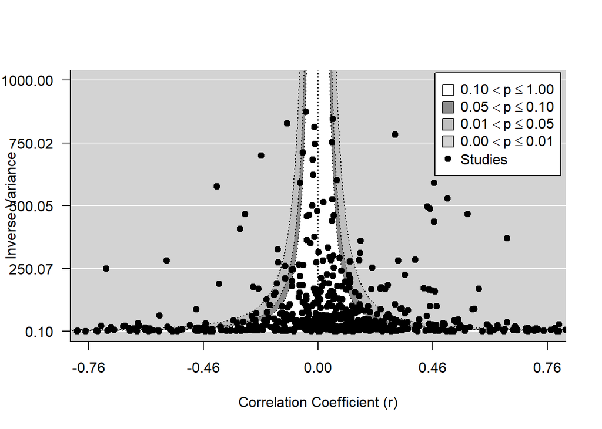

```r
#funnel plot
dfeffect %>% filter(dfeffect$sampling.variance > 0.00001) %>%
  funnel(x = dfeffect$effect.size, vi = dfeffect$sampling.variance, yaxis = "vinv", digits = 2, level = c(0.1, 0.05, 0.01), shade = c("white", "gray55", "gray75"), las = 1, xlab = "Correlation Coefficient (r)", atransf = tanh, legend = TRUE, ylim = c(0.1, 1000), xlim = c(-1, 1))
```

The studies within the confidence intervals are indicative of sampling variations accounting for the differences in effect size. As such, studies outside the zone are significant in their findings. Due to the non-lack of studies on either side of the funnel, it can be determined that there is no file drawer effect in place since it is evenly spread and not skewed due to bias.

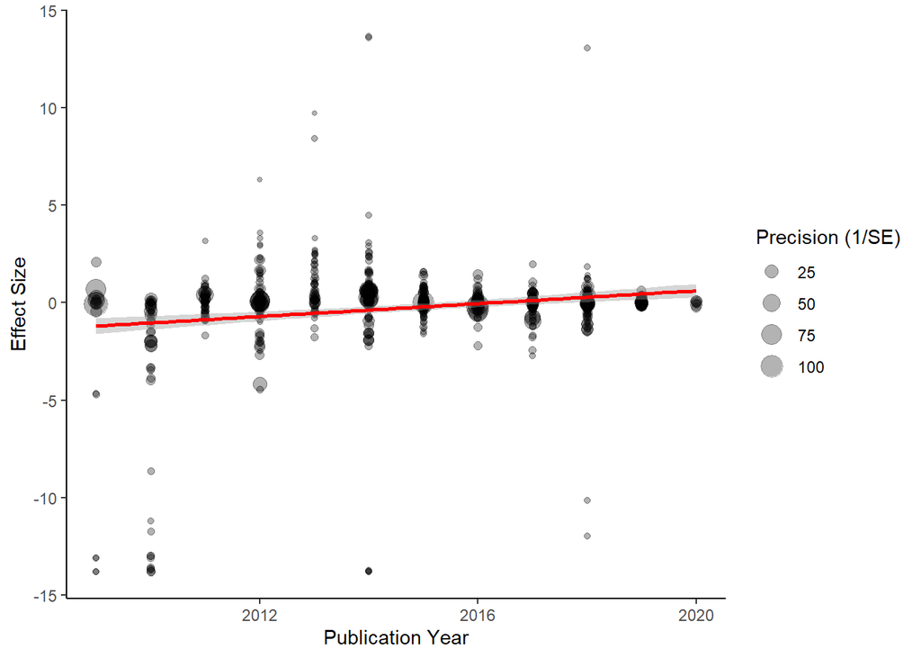

```r
#time lag plot
dfeffect %>% filter(dfeffect$sampling.variance > 0.00001) %>%
  ggplot(aes(y = effect.size, x = Year.Pub, size = 1/sqrt(sampling.variance))) +
  geom_point(alpha = 0.3) +
  geom_smooth(method = lm, col = "red", show.legend = FALSE) +
  labs(x = "Publication Year", y = "Effect Size", size = "Precision (1/SE)") +
  theme_classic()
```

```r
#meta regression model for time lag bias
metareg_time <- rma.mv(effect.size ~ Year.Pub, V = sampling.variance, random = list(~1 | Study/Species/Behavioural.metric), test = "t", dfs = "contain", data = dfeffect)
metareg_time
```

```
##
## Multivariate Meta-Analysis Model (k = 801; method: REML)
##
## Variance Components:
##
##             estim    sqrt  nlvls  fixed                            factor
## sigma^2.1  0.2457  0.4957     92     no                             Study
## sigma^2.2  0.1792  0.4233    118     no                     Study/Species
## sigma^2.3  3.9841  1.9960    798     no  Study/Species/Behavioural.metric
##
## Test for Residual Heterogeneity:
## QE(df = 799) = 128790497.0562, p-val < .0001
##
## Test of Moderators (coefficient 2):
## F(df1 = 1, df2 = 90) = 7.4433, p-val = 0.0077
##
## Model Results:
##
##            estimate       se     tval  df    pval      ci.lb     ci.ub
## intrcpt   -221.5057  81.1391  -2.7299  90  0.0076  -382.7026  -60.3087  **
## Year.Pub     0.1099   0.0403   2.7282  90  0.0077     0.0299    0.1899  **
##
## ---
## Signif. codes:  0 '***' 0.001 '**' 0.01 '*' 0.05 '.' 0.1 ' ' 1
```

```r
#meta regression model for both time lag and file drawer bias
dfeffect_c <- dfeffect
dfeffect_c <- dfeffect_c %>%
  mutate(Year_c = Year.Pub - mean(Year.Pub))

metareg_file <- rma.mv(effect.size ~ Year_c + sampling.variance, V = sampling.variance, random = list(~1 | Study/Species/Behavioural.metric), test = "t", dfs = "contain", data = dfeffect_c)
metareg_file
```

```
##
## Multivariate Meta-Analysis Model (k = 801; method: REML)
##
## Variance Components:
##
##             estim    sqrt  nlvls  fixed                            factor
## sigma^2.1  0.2457  0.4957     92     no                             Study
## sigma^2.2  0.1792  0.4233    118     no                     Study/Species
## sigma^2.3  3.9841  1.9960    798     no  Study/Species/Behavioural.metric
##
## Test for Residual Heterogeneity:
## QE(df = 798) = 128790497.0561, p-val < .0001
##
## Test of Moderators (coefficients 2:3):
## F(df1 = 2, df2 = 89) = 3.7217, p-val = 0.0280
##
## Model Results:
##
##                    estimate      se     tval   df    pval    ci.lb   ci.ub
## intrcpt             -0.1479  0.1084  -1.3651   89  0.1757  -0.3633  0.0674
## Year_c               0.1099  0.0403   2.7282   89  0.0077   0.0298  0.1899  **
## sampling.variance    0.0000  0.0001   0.0012  798  0.9990  -0.0002  0.0002
##
## ---
## Signif. codes:  0 '***' 0.001 '**' 0.01 '*' 0.05 '.' 0.1 ' ' 1
```

From the multilevel meta-regression results, there appears to be no evidence for lag-time regression, since the effect size appears to increase through the publication years. This is conveyed by the positive estimate for the year_c results from the analysis, ignoring the significant p value since the lag time regression only applies for decreasing effect sizes over time.

There is also no file drawer biases in the studies, demonstrated by the non-significant p value for the sampling variance. This is justified further by the funnel plot, with even distribution across the x axis demonstrating no bias due to a result given.

## Conclusion

Further anlysis of the meta data is required to accurately determine the results of the ocean acidification research and conclusions.

https://github.com/CalebNeill/BIOL3207_Assignment_2